# Business Statistics End of Term Assessment IB94X0 2023-2024 #1

## Data Preparation

```r
#Filtering for -ve values
bike.data.filtered <- filter(bike.data, Hires<60000)

# Since we have data from 2010, but the policies started coming into effect due to covid, i.e, after 2019, it would be ideal to subset the data starting from 2019. This is because, 2019 data serves as a baseline or control. It shows what the bike hire numbers looked like under "normal" circumstances, without the influence of the COVID-19 policies. 2020 reflects the period when the policies were in effect. Analyzing this data can help us understand how each policy might have influenced the bike hire numbers.


bike.data.filtered<- filter(bike.data.filtered, date> as.POSIXct("2019-01-01"))

#Converting character columns into factors
cols_name <- c("day","month", "eat_out_to_help_out","wfh","rule_of_6_indoors")
bike.data.filtered[cols_name] <- lapply(bike.data.filtered[cols_name] , factor)

bike.data.filtered <- bike.data.filtered %>%
  mutate(month = factor(month, levels = c("Jan","Feb","Mar","Apr", "May", "Jun", "Jul", "Aug","Sep","Oct","Nov","Dec"), labels=c("January", "February", "March", "April", "May", "June", "July", "August", "September", "October", "November", "December")))


bike.data.filtered <- bike.data.filtered %>%
  mutate(day = factor(day, levels = c("Sun","Mon","Tue","Wed", "Thu", "Fri", "Sat"), labels=c("Sunday","Monday","Tuesday","Wednesday","Thursday","Friday","Saturday")))

#Check for duplicates
bike.data.filtered$date[duplicated(bike.data.filtered$date)]
```

```
## [1] "2021-12-13"
```

```r
#Removing Duplicates
bike.data.filtered<- bike.data.filtered[!duplicated(bike.data.filtered$date),]
```

## Effect of Policies on bike hires: Work From Home, Rule of 6 Indoors, and Eat Out to Help Out scheme.

```r
#Check the effect of policies on bike hires using 'lm' function
m_bikes_policies<-lm(Hires~wfh+eat_out_to_help_out+rule_of_6_indoors, data = bike.data.filtered)

summary(m_bikes_policies)
```

```
##
## Call:
## lm(formula = Hires ~ wfh + eat_out_to_help_out + rule_of_6_indoors,
##     data = bike.data.filtered)
##
## Residuals:
##      Min       1Q   Median       3Q      Max
## -27046.8  -6056.1   -332.8   6357.4  30469.2
##
## Coefficients:
##                      Estimate Std. Error t value Pr(>|t|)
## (Intercept)           29784.8      381.8  78.011  < 2e-16 ***
## wfh1                  -2737.9      482.0  -5.681 1.57e-08 ***
## eat_out_to_help_out1   6633.7     1824.3   3.636 0.000285 ***
## rule_of_6_indoors1     8456.3     1001.9   8.440  < 2e-16 ***
## ---
## Signif. codes:  0 '***' 0.001 '**' 0.01 '*' 0.05 '.' 0.1 ' ' 1
##
## Residual standard error: 9440 on 1722 degrees of freedom
## Multiple R-squared:  0.06061,    Adjusted R-squared:  0.05898
## F-statistic: 37.04 on 3 and 1722 DF,  p-value: < 2.2e-16
```

```r
# Estimation Approach - Confidence intervals
cbind(coef(m_bikes_policies),confint(m_bikes_policies))
```

```
##                                    2.5 %    97.5 %
## (Intercept)          29784.751 29035.908 30533.595
## wfh1                 -2737.903 -3683.197 -1792.608
## eat_out_to_help_out1  6633.677  3055.535 10211.819
## rule_of_6_indoors1    8456.263  6491.135 10421.392
```

- We observe a significant positive effect on bike hires due to the eat out to help out and rule of 6 indoors polcies. The work from home policy shows a significant negative effect.
- When a Work from Home policy is implemented, the bikes hired decreases by 2738 bikes t(1722) = -5.681, p< 0.001, 95% CI[-3683, -1793]. This means when the wfh policy is in place,the number of bike hires decreases.
- When an Eat out to help out policy is implemented, the bikes hired increases by 6634 bikes, t(1722) = 3.636, p<0.001, 95% CI[3056, 10211]. People could have used bikes to get to the eating spots.
- When a Rule of 6 Indoors policy is implemented, the bikes hired increases by 8456 bikes, t(1722) = 8.440, p<0.001, 95% CI[6491, 10421]. People may have used bikes to get to social gatherings.

```r
#Calculate Estimation Means
m.bikes.emm <- emmeans(m_bikes_policies, ~ wfh+eat_out_to_help_out+rule_of_6_indoors)

m.bikes.emm
```

```
##  wfh eat_out_to_help_out rule_of_6_indoors emmean   SE   df lower.CL upper.CL
##  0   0                   0                  29785  382 1722    29036    30534
##  1   0                   0                  27047  298 1722    26463    27631
##  0   1                   0                  36418 1784 1722    32920    39917
##  1   1                   0                  33681 1848 1722    30056    37305
##  0   0                   1                  38241 1060 1722    36162    40320
##  1   0                   1                  35503  964 1722    33612    37394
##  0   1                   1                  44875 2046 1722    40862    48888
##  1   1                   1                  42137 2069 1722    38078    46195
##
## Confidence level used: 0.95
```

```r
#Check Multicollinearity
vif(m_bikes_policies)
```

```
##                 wfh eat_out_to_help_out   rule_of_6_indoors
##            1.049739            1.028840            1.021358
```

- When there are no policies, the average bike hires is 29785 95% CI[29036, 30534]
- When there is only a work from home policy in place, the average bike hires decreases to 27047 95% CI[26463, 27631]
- When there is only an eat out to help out policy in place, the average bike hires increases to 36418 95% CI[32920, 39917]
- When there is only a rule of 6 indoors policy in place, the average bike hires increases to 38241 95% CI[36162, 40320]

## Effect of Bike hires - Controlling for time factors - Day, Month, Year

```r
#Controlling for year independently
m_bikes_year <- lm (Hires ~ wfh + rule_of_6_indoors + eat_out_to_help_out + as.factor(year), data = bike.data.filtered)

summary(m_bikes_year)
```

```
##
## Call:
## lm(formula = Hires ~ wfh + rule_of_6_indoors + eat_out_to_help_out +
##     as.factor(year), data = bike.data.filtered)
##
## Residuals:
##    Min     1Q Median     3Q    Max
## -31332  -6030    -46   6254  33108
##
## Coefficients:
##                      Estimate Std. Error t value Pr(>|t|)
## (Intercept)           28601.1      475.6  60.143  < 2e-16 ***
## wfh1                  -6289.3      743.9  -8.454  < 2e-16 ***
## rule_of_6_indoors1     9945.1     1033.4   9.624  < 2e-16 ***
## eat_out_to_help_out1   5720.9     1855.5   3.083  0.00208 **
## as.factor(year)2020    2096.4      853.8   2.455  0.01418 *
## as.factor(year)2021    3397.5      800.6   4.244 2.32e-05 ***
## as.factor(year)2022    9020.4     1003.2   8.992  < 2e-16 ***
## as.factor(year)2023    1872.3     1039.8   1.801  0.07192 .
## ---
## Signif. codes:  0 '***' 0.001 '**' 0.01 '*' 0.05 '.' 0.1 ' ' 1
##
## Residual standard error: 9073 on 1718 degrees of freedom
## Multiple R-squared:  0.1342, Adjusted R-squared:  0.1307
## F-statistic: 38.04 on 7 and 1718 DF,  p-value: < 2.2e-16
```

```r
#Check the effect of year on policies with interaction
m_bikes_year_intr <- lm (Hires ~ (wfh + rule_of_6_indoors + eat_out_to_help_out) * as.factor(year), data = bike.data.filtered)

summary(m_bikes_year_intr)
```

```
##
## Call:
## lm(formula = Hires ~ (wfh + rule_of_6_indoors + eat_out_to_help_out) *
##     as.factor(year), data = bike.data.filtered)
##
## Residuals:
##      Min       1Q   Median       3Q      Max
## -31332.2  -5661.4     26.5   5978.4  30679.8
##
## Coefficients: (10 not defined because of singularities)
##                                          Estimate Std. Error t value Pr(>|t|)
## (Intercept)                               28601.1      463.4  61.724  < 2e-16 ***
## wfh1                                     -13098.7     1017.6 -12.872  < 2e-16 ***
## rule_of_6_indoors1                        15532.1     1322.1  11.748  < 2e-16 ***
## eat_out_to_help_out1                       9935.5     1894.7   5.244 1.77e-07 ***
## as.factor(year)2020                       -2118.2     1006.5  -2.104   0.0355 *
## as.factor(year)2021                        6481.5      861.9   7.520 8.75e-14 ***
## as.factor(year)2022                       15829.8     1210.6  13.076  < 2e-16 ***
## as.factor(year)2023                        8681.7     1239.6   7.004 3.57e-12 ***
## wfh1:as.factor(year)2020                  13452.0     1467.8   9.165  < 2e-16 ***
## wfh1:as.factor(year)2021                       NA         NA      NA       NA
## wfh1:as.factor(year)2022                       NA         NA      NA       NA
## wfh1:as.factor(year)2023                       NA         NA      NA       NA
## rule_of_6_indoors1:as.factor(year)2020    -9958.6     2093.2  -4.758 2.12e-06 ***
## rule_of_6_indoors1:as.factor(year)2021         NA         NA      NA       NA
## rule_of_6_indoors1:as.factor(year)2022         NA         NA      NA       NA
## rule_of_6_indoors1:as.factor(year)2023         NA         NA      NA       NA
## eat_out_to_help_out1:as.factor(year)2020       NA         NA      NA       NA
## eat_out_to_help_out1:as.factor(year)2021       NA         NA      NA       NA
## eat_out_to_help_out1:as.factor(year)2022       NA         NA      NA       NA
## eat_out_to_help_out1:as.factor(year)2023       NA         NA      NA       NA
## ---
## Signif. codes:  0 '***' 0.001 '**' 0.01 '*' 0.05 '.' 0.1 ' ' 1
##
## Residual standard error: 8841 on 1716 degrees of freedom
## Multiple R-squared:  0.1789, Adjusted R-squared:  0.1746
## F-statistic: 41.55 on 9 and 1716 DF,  p-value: < 2.2e-16
```

```r
#Compare the models using ANOVA
anova(m_bikes_year,m_bikes_year_intr)
```

```
## Analysis of Variance Table
##
## Model 1: Hires ~ wfh + rule_of_6_indoors + eat_out_to_help_out + as.factor(year)
## Model 2: Hires ~ (wfh + rule_of_6_indoors + eat_out_to_help_out) * as.factor(year)
##   Res.Df        RSS Df  Sum of Sq      F    Pr(>F)
## 1   1718 1.4142e+11
## 2   1716 1.3412e+11  2 7307899575 46.752 < 2.2e-16 ***
## ---
## Signif. codes:  0 '***' 0.001 '**' 0.01 '*' 0.05 '.' 0.1 ' ' 1
```

```r
#Calculate confidence intervals
cbind(coef(m_bikes_year_intr),confint(m_bikes_year_intr))
```

```
##                                                          2.5 %      97.5 %
## (Intercept)                               28601.118  27692.283  29509.9533
## wfh1                                     -13098.746 -15094.689 -11102.8036
## rule_of_6_indoors1                        15532.107  12938.913  18125.3010
## eat_out_to_help_out1                       9935.528   6219.459  13651.5969
## as.factor(year)2020                       -2118.218  -4092.399   -144.0368
## as.factor(year)2021                        6481.537   4791.138   8171.9363
## as.factor(year)2022                       15829.788  13455.335  18204.2406
## as.factor(year)2023                        8681.720   6250.449  11112.9904
## wfh1:as.factor(year)2020                  13452.025  10573.087  16330.9622
## wfh1:as.factor(year)2021                         NA         NA          NA
## wfh1:as.factor(year)2022                         NA         NA          NA
## wfh1:as.factor(year)2023                         NA         NA          NA
## rule_of_6_indoors1:as.factor(year)2020    -9958.612 -14064.149  -5853.0746
## rule_of_6_indoors1:as.factor(year)2021           NA         NA          NA
## rule_of_6_indoors1:as.factor(year)2022           NA         NA          NA
## rule_of_6_indoors1:as.factor(year)2023           NA         NA          NA
## eat_out_to_help_out1:as.factor(year)2020         NA         NA          NA
## eat_out_to_help_out1:as.factor(year)2021         NA         NA          NA
## eat_out_to_help_out1:as.factor(year)2022         NA         NA          NA
## eat_out_to_help_out1:as.factor(year)2023         NA         NA          NA
```

- In a baseline analysis for the year 2019 (Pre-COVID), the average number of bike hires was established at 28,601, t(1716)=61.724, 95% CI[27692, 29510], disregarding other factors.
- The introduction of Work from Home (WFH) policies led to a significant decrease in bike hires, averaging a reduction of 13,099, t(1716) =-12.872 (p < 0.001), 95% CI[-15095, -11103].
- In contrast, the implementation of the ‘Rule of 6 Indoors’ policy had significantly increased by of 15,532, t(1716) =11.748 , (p<0.001), 95% CI [12939, 18125] in bike hires.
- Additionally, the ‘Eat Out to Help Out’ scheme correlated with an average increase of 9,936 hires, t(1716)= 5.244, (p < 0.001),95% CI[6219, 13651].
- The data also revealed significant interactions between these factors and specific years. For instance, there was an additional increase of 13,452 hires, (p < 0.001)CI[10573, 16330] in 2020 when WFH was in effect.
- The combination of the ‘Rule of 6 Indoors’ with the year 2020 showed a significant decrease in hires by 9,959 (p < 0.001) 95% CI[-14064, -5853]
- ‘Eat Out to Help Out’ has no significant interaction with the years.
- NA values indicate that since the policies were implemented only during COVID that is in the year 2020, there no data available for other years.

```r
#Controlling for month independently
m_bikes_month <- lm (Hires ~ wfh + rule_of_6_indoors + eat_out_to_help_out  + month, data = bike.data.filtered)

#Controlling for month using interaction
m_bikes_month_intr <- lm (Hires ~(wfh + rule_of_6_indoors + eat_out_to_help_out) * month, data = bike.data.filtered)

summary(m_bikes_month_intr)
```

```
##
## Call:
## lm(formula = Hires ~ (wfh + rule_of_6_indoors + eat_out_to_help_out) *
##     month, data = bike.data.filtered)
##
## Residuals:
##    Min     1Q Median     3Q    Max
## -27431  -5072    423   5111  32269
##
## Coefficients: (18 not defined because of singularities)
##                                     Estimate Std. Error t value Pr(>|t|)
## (Intercept)                          22644.6      971.2  23.316  < 2e-16 ***
## wfh1                                 -4047.6     1249.7  -3.239 0.001224 **
## rule_of_6_indoors1                    -894.0     2201.5  -0.406 0.684730
## eat_out_to_help_out1                  1055.1     1714.6   0.615 0.538400
## monthFebruary                          864.9     1397.4   0.619 0.536018
## monthMarch                            1983.4     1472.2   1.347 0.178087
## monthApril                            7027.0     1691.5   4.154 3.42e-05 ***
## monthMay                              9824.6     1673.1   5.872 5.16e-09 ***
## monthJune                            10903.2     1691.5   6.446 1.49e-10 ***
## monthJuly                            14270.5     1500.3   9.512  < 2e-16 ***
## monthAugust                          12718.7     1352.2   9.406  < 2e-16 ***
## monthSeptember                       14208.5     1300.3  10.927  < 2e-16 ***
## monthOctober                          9009.7     1367.9   6.586 5.99e-11 ***
## monthNovember                         5258.0     1379.2   3.812 0.000143 ***
## monthDecember                        -1619.1     1500.3  -1.079 0.280640
## wfh1:monthFebruary                    2850.8     1804.5   1.580 0.114333
## wfh1:monthMarch                       3718.1     1821.7   2.041 0.041409 *
## wfh1:monthApril                       1151.3     1989.8   0.579 0.562936
## wfh1:monthMay                         3481.8     1990.1   1.750 0.080381 .
## wfh1:monthJune                        6466.0     2035.0   3.177 0.001512 **
## wfh1:monthJuly                        2557.7     1867.7   1.369 0.171033
## wfh1:monthAugust                      1000.6     1841.3   0.543 0.586885
## wfh1:monthSeptember                  -5374.6     1763.5  -3.048 0.002342 **
## wfh1:monthOctober                      246.6     1934.1   0.128 0.898557
## wfh1:monthNovember                     908.3     1865.4   0.487 0.626361
## wfh1:monthDecember                     460.6     1894.4   0.243 0.807910
## rule_of_6_indoors1:monthFebruary          NA         NA      NA       NA
## rule_of_6_indoors1:monthMarch             NA         NA      NA       NA
## rule_of_6_indoors1:monthApril             NA         NA      NA       NA
```

[output cut: 10 more lines]

```
## eat_out_to_help_out1:monthApril           NA         NA      NA       NA
## eat_out_to_help_out1:monthMay             NA         NA      NA       NA
## eat_out_to_help_out1:monthJune            NA         NA      NA       NA
## eat_out_to_help_out1:monthJuly            NA         NA      NA       NA
## eat_out_to_help_out1:monthAugust          NA         NA      NA       NA
## eat_out_to_help_out1:monthSeptember       NA         NA      NA       NA
## eat_out_to_help_out1:monthOctober         NA         NA      NA       NA
## eat_out_to_help_out1:monthNovember        NA         NA      NA       NA
## eat_out_to_help_out1:monthDecember        NA         NA      NA       NA
## ---
## Signif. codes:  0 '***' 0.001 '**' 0.01 '*' 0.05 '.' 0.1 ' ' 1
##
## Residual standard error: 7585 on 1696 degrees of freedom
## Multiple R-squared:  0.4026, Adjusted R-squared:  0.3924
## F-statistic: 39.41 on 29 and 1696 DF,  p-value: < 2.2e-16
```

```r
#Compare the models using ANOVA
anova(m_bikes_month,m_bikes_month_intr)
```

```
## Analysis of Variance Table
##
## Model 1: Hires ~ wfh + rule_of_6_indoors + eat_out_to_help_out + month
## Model 2: Hires ~ (wfh + rule_of_6_indoors + eat_out_to_help_out) * month
##   Res.Df        RSS Df  Sum of Sq      F    Pr(>F)
## 1   1711 1.0086e+11
## 2   1696 9.7580e+10 15 3284160270 3.8054 1.055e-06 ***
## ---
## Signif. codes:  0 '***' 0.001 '**' 0.01 '*' 0.05 '.' 0.1 ' ' 1
```

```r
#Calculating Confidence Intervals
cbind(coef(m_bikes_month_intr),confint(m_bikes_month_intr))
```

```
##                                                     2.5 %    97.5 %
## (Intercept)                         22644.6393 20739.7887 24549.490
## wfh1                                -4047.6286 -6498.8346 -1596.423
## rule_of_6_indoors1                   -894.0136 -5212.0151  3423.988
## eat_out_to_help_out1                 1055.1209 -2307.9160  4418.158
## monthFebruary                         864.9221 -1875.7969  3605.641
## monthMarch                           1983.3819  -904.1306  4870.894
## monthApril                           7026.9607  3709.3837 10344.538
## monthMay                             9824.6187  6543.1067 13106.131
## monthJune                           10903.1607  7585.5837 14220.738
## monthJuly                           14270.5425 11327.9559 17213.129
## monthAugust                         12718.6683 10066.5706 15370.766
## monthSeptember                      14208.5089 11658.0993 16758.918
## monthOctober                         9009.7155  6326.7342 11692.697
## monthNovember                        5257.9940  2552.9272  7963.061
## monthDecember                       -1619.1393 -4561.7259  1323.447
## wfh1:monthFebruary                   2850.7934  -688.4786  6390.065
## wfh1:monthMarch                      3718.1166   145.0102  7291.223
## wfh1:monthApril                      1151.2786 -2751.3791  5053.936
## wfh1:monthMay                        3481.7951  -421.5817  7385.172
## wfh1:monthJune                       6466.0125  2474.7268 10457.298
## wfh1:monthJuly                       2557.7048 -1105.4530  6220.863
## wfh1:monthAugust                     1000.6488 -2610.7268  4612.024
## wfh1:monthSeptember                 -5374.5666 -8833.3932 -1915.740
## wfh1:monthOctober                     246.5998 -3546.8144  4040.014
## wfh1:monthNovember                    908.3453 -2750.3802  4567.071
## wfh1:monthDecember                    460.6411 -3254.9300  4176.212
## rule_of_6_indoors1:monthFebruary            NA         NA        NA
## rule_of_6_indoors1:monthMarch               NA         NA        NA
## rule_of_6_indoors1:monthApril               NA         NA        NA
## rule_of_6_indoors1:monthMay          1245.7224 -4711.5364  7202.981
## rule_of_6_indoors1:monthJune         4382.2963  -962.5224  9727.115
## rule_of_6_indoors1:monthJuly         4138.0889 -1634.3912  9910.569
## rule_of_6_indoors1:monthAugust              NA         NA        NA
## rule_of_6_indoors1:monthSeptember    6402.2628   625.9695 12178.556
## rule_of_6_indoors1:monthOctober             NA         NA        NA
## rule_of_6_indoors1:monthNovember            NA         NA        NA
## rule_of_6_indoors1:monthDecember            NA         NA        NA
## eat_out_to_help_out1:monthFebruary          NA         NA        NA
## eat_out_to_help_out1:monthMarch             NA         NA        NA
## eat_out_to_help_out1:monthApril             NA         NA        NA
## eat_out_to_help_out1:monthMay               NA         NA        NA
## eat_out_to_help_out1:monthJune              NA         NA        NA
## eat_out_to_help_out1:monthJuly              NA         NA        NA
## eat_out_to_help_out1:monthAugust            NA         NA        NA
## eat_out_to_help_out1:monthSeptember         NA         NA        NA
## eat_out_to_help_out1:monthOctober           NA         NA        NA
## eat_out_to_help_out1:monthNovember          NA         NA        NA
## eat_out_to_help_out1:monthDecember          NA         NA        NA
```

```r
#Controlling the effect of day independently

m_bikes_day<- lm (Hires ~(wfh + rule_of_6_indoors + eat_out_to_help_out) + day, data = bike.data.filtered)

##Controlling the effect of day using interaction
m_bikes_day_intr <- lm (Hires ~(wfh + rule_of_6_indoors + eat_out_to_help_out) * day, data = bike.data.filtered)

summary(m_bikes_day_intr)
```

```
##
## Call:
## lm(formula = Hires ~ (wfh + rule_of_6_indoors + eat_out_to_help_out) *
##     day, data = bike.data.filtered)
##
## Residuals:
##    Min     1Q Median     3Q    Max
## -28248  -6168   -623   6145  32133
##
## Coefficients:
##                                   Estimate Std. Error t value Pr(>|t|)
## (Intercept)                        24365.2      988.4  24.651  < 2e-16 ***
## wfh1                                1018.3     1251.1   0.814 0.415814
## rule_of_6_indoors1                  9886.5     2669.4   3.704 0.000219 ***
## eat_out_to_help_out1               13110.6     4738.0   2.767 0.005717 **
## dayMonday                           5569.0     1394.7   3.993 6.81e-05 ***
## dayTuesday                          7823.0     1405.9   5.564 3.05e-08 ***
## dayWednesday                        8392.4     1401.8   5.987 2.60e-09 ***
## dayThursday                         7814.3     1401.8   5.575 2.88e-08 ***
## dayFriday                           5979.9     1401.8   4.266 2.10e-05 ***
## daySaturday                         2513.8     1397.8   1.798 0.072291 .
## wfh1:dayMonday                     -5693.2     1764.2  -3.227 0.001274 **
## wfh1:dayTuesday                    -5521.2     1774.5  -3.111 0.001893 **
## wfh1:dayWednesday                  -6236.9     1770.1  -3.523 0.000437 ***
## wfh1:dayThursday                   -5242.9     1770.1  -2.962 0.003100 **
## wfh1:dayFriday                     -4153.9     1771.3  -2.345 0.019134 *
## wfh1:daySaturday                     350.5     1770.5   0.198 0.843116
## rule_of_6_indoors1:dayMonday       -4908.9     3704.7  -1.325 0.185341
## rule_of_6_indoors1:dayTuesday      -2477.5     3712.2  -0.667 0.504614
## rule_of_6_indoors1:dayWednesday     -451.4     3711.8  -0.122 0.903217
## rule_of_6_indoors1:dayThursday     -1376.1     3711.8  -0.371 0.710883
## rule_of_6_indoors1:dayFriday       -4982.8     3712.2  -1.342 0.179686
## rule_of_6_indoors1:daySaturday      4579.6     3775.5   1.213 0.225304
## eat_out_to_help_out1:dayMonday     -7900.0     6699.9  -1.179 0.238517
## eat_out_to_help_out1:dayTuesday    -7430.0     6702.2  -1.109 0.267767
## eat_out_to_help_out1:dayWednesday  -9240.9     6701.4  -1.379 0.168090
## eat_out_to_help_out1:dayThursday   -9756.3     6701.4  -1.456 0.145615
## eat_out_to_help_out1:dayFriday     -9224.9     6701.4  -1.377 0.168828
## eat_out_to_help_out1:daySaturday   -1941.5     6700.5  -0.290 0.772037
## ---
## Signif. codes:  0 '***' 0.001 '**' 0.01 '*' 0.05 '.' 0.1 ' ' 1
##
## Residual standard error: 9268 on 1698 degrees of freedom
## Multiple R-squared:  0.1072, Adjusted R-squared:  0.09299
## F-statistic:  7.55 on 27 and 1698 DF,  p-value: < 2.2e-16
```

```r
#Compare the models using ANOVA
anova(m_bikes_day,m_bikes_day_intr)
```

```
## Analysis of Variance Table
##
## Model 1: Hires ~ (wfh + rule_of_6_indoors + eat_out_to_help_out) + day
## Model 2: Hires ~ (wfh + rule_of_6_indoors + eat_out_to_help_out) * day
##   Res.Df        RSS Df  Sum of Sq      F    Pr(>F)
## 1   1716 1.4965e+11
## 2   1698 1.4584e+11 18 3810437177 2.4648 0.0005766 ***
## ---
## Signif. codes:  0 '***' 0.001 '**' 0.01 '*' 0.05 '.' 0.1 ' ' 1
```

```r
#Calculate confidence intervals
cbind(coef(m_bikes_day_intr),confint(m_bikes_day_intr))
```

```
##                                                    2.5 %     97.5 %
## (Intercept)                       24365.1763  22426.5909 26303.7617
## wfh1                               1018.2791  -1435.5906  3472.1488
## rule_of_6_indoors1                 9886.4892   4650.9215 15122.0568
## eat_out_to_help_out1              13110.5737   3817.6337 22403.5137
## dayMonday                          5568.9785   2833.4125  8304.5446
## dayTuesday                         7822.9868   5065.5488 10580.4248
## dayWednesday                       8392.4206   5643.0163 11141.8248
## dayThursday                        7814.3017   5064.8974 10563.7059
## dayFriday                          5979.8853   3230.4807  8729.2898
## daySaturday                        2513.7882   -227.7859  5255.3623
## wfh1:dayMonday                    -5693.1748  -9153.3569 -2232.9927
## wfh1:dayTuesday                   -5521.1965  -9001.5658 -2040.8272
## wfh1:dayWednesday                 -6236.9268  -9708.7845 -2765.0692
## wfh1:dayThursday                  -5242.9383  -8714.7960 -1771.0807
## wfh1:dayFriday                    -4153.8882  -7627.9781  -679.7982
## wfh1:daySaturday                    350.4521  -3122.1411  3823.0454
## rule_of_6_indoors1:dayMonday      -4908.8762 -12175.2122  2357.4597
## rule_of_6_indoors1:dayTuesday     -2477.5147  -9758.5698  4803.5405
## rule_of_6_indoors1:dayWednesday    -451.4131  -7731.5104  6828.6842
## rule_of_6_indoors1:dayThursday    -1376.0693  -8656.1666  5904.0280
## rule_of_6_indoors1:dayFriday      -4982.8423 -12263.8792  2298.1946
## rule_of_6_indoors1:daySaturday     4579.6406  -2825.5091 11984.7904
## eat_out_to_help_out1:dayMonday    -7899.9785 -21040.9283  5240.9713
## eat_out_to_help_out1:dayTuesday   -7429.9868 -20575.5072  5715.5335
## eat_out_to_help_out1:dayWednesday -9240.9206 -22384.7581  3902.9169
## eat_out_to_help_out1:dayThursday  -9756.3017 -22900.1392  3387.5358
## eat_out_to_help_out1:dayFriday    -9224.8853 -22368.7229  3918.9523
## eat_out_to_help_out1:daySaturday  -1941.5382 -15083.7400 11200.6637
```

- The analysis reveals significant variations in the number of bike hires across different days of the week when considering work from home (WFH), rule of 6 indoors, and the ‘Eat Out to Help Out’ policy.
- The interaction terms suggest that the WFH policy affects the daily pattern of bike hires. For instance, the negative interaction between WFH and days of the week are as follows:
  - Mondays decreases by 5693, 95% CI [-9153, -2233], t(1698) = -3.227, p = 0.001).
  - Tuesdays decreases by 5521, 95% CI [-9002, -2041], t(1698) = -3.111, p = 0.002),
  - Wednesdays decreases by 6237, 95% CI [-9709, -2765], t(1698) = -3.523, p < 0.001),
  - Thursdays decreases by 5242, 95% CI [-8715, -1771], t(1698) = -2.962, p = 0.003), and
  - Fridays decreases by 4154, 95% CI [-7628, -680], t(1698) = -2.345, p = 0.019).
- There are no significant interactions between the ‘Rule of 6 Indoors’ or ‘Eat Out to Help Out’ policies with specific days of the week, suggesting these policies do not have a day-specific influence on the number of bike hires.

```r
#Calculate estimation means
m.bikes.days.emm<-emmeans(m_bikes_day_intr, ~day)
```

```
## NOTE: Results may be misleading due to involvement in interactions
```

```r
m.bikes.days.emm
```

```
##  day       emmean   SE   df lower.CL upper.CL
##  Sunday     36373 2650 1698    31175    41570
##  Monday     32691 2629 1698    27535    37846
##  Tuesday    36481 2627 1698    31328    41635
##  Wednesday  36801 2627 1698    31647    41954
##  Thursday   35999 2627 1698    30846    41153
##  Friday     33172 2627 1698    28018    38325
##  Saturday   40381 2650 1698    35184    45578
##
## Results are averaged over the levels of: wfh, rule_of_6_indoors, eat_out_to_help_out
## Confidence level used: 0.95
```

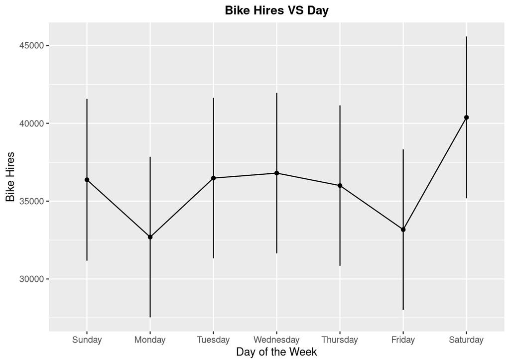

```r
#Plotting emmeans for each day of the week
ggplot(summary(m.bikes.days.emm), aes(y = emmean, x = day, ymin = lower.CL, ymax = upper.CL))+
  geom_point()+
  geom_linerange()+
  labs(x= "Day of the Week", y = "Bike Hires", title = "Bike Hires VS Day")+
  geom_line(aes(group = 1))+
  theme(plot.title = element_text(size = 12, face = "bold", hjust = 0.5))
```

```r
#Build a final model with the most suitable predictors
m_bikes_final <- lm (Hires ~ wfh + rule_of_6_indoors + as.factor(year) + eat_out_to_help_out + wfh * day + month, data = bike.data.filtered)

summary(m_bikes_final)
```

```
##
## Call:
## lm(formula = Hires ~ wfh + rule_of_6_indoors + as.factor(year) +
##     eat_out_to_help_out + wfh * day + month, data = bike.data.filtered)
##
## Residuals:
##    Min     1Q Median     3Q    Max
## -36624  -4115    544   4096  29486
##
## Coefficients:
##                      Estimate Std. Error t value Pr(>|t|)
## (Intercept)           15359.3      927.1  16.567  < 2e-16 ***
## wfh1                  -2920.0     1033.4  -2.826 0.004775 **
## rule_of_6_indoors1     3269.7      825.6   3.960 7.80e-05 ***
## as.factor(year)2020    3425.2      661.3   5.180 2.49e-07 ***
## as.factor(year)2021    4647.9      618.9   7.510 9.53e-14 ***
## as.factor(year)2022    9213.6      791.7  11.637  < 2e-16 ***
## as.factor(year)2023     469.1      823.0   0.570 0.568748
## eat_out_to_help_out1   -545.9     1523.8  -0.358 0.720178
## dayMonday              5062.4     1008.5   5.020 5.72e-07 ***
## dayTuesday             7379.2     1016.9   7.256 6.02e-13 ***
## dayWednesday           7977.1     1014.2   7.866 6.48e-15 ***
## dayThursday            7402.3     1014.0   7.300 4.41e-13 ***
## dayFriday              5573.6     1014.0   5.497 4.46e-08 ***
## daySaturday            2380.2     1011.1   2.354 0.018688 *
## monthFebruary          2623.9      799.4   3.282 0.001051 **
## monthMarch             4914.1      782.8   6.277 4.37e-10 ***
## monthApril             8433.2      796.2  10.592  < 2e-16 ***
## monthMay              12811.7      794.3  16.129  < 2e-16 ***
## monthJune             16714.1      811.7  20.592  < 2e-16 ***
## monthJuly             16359.1      787.3  20.779  < 2e-16 ***
## monthAugust           13069.1      830.3  15.741  < 2e-16 ***
## monthSeptember        11683.4      799.4  14.616  < 2e-16 ***
## monthOctober           7634.0      838.4   9.106  < 2e-16 ***
## monthNovember          4775.4      840.5   5.681 1.57e-08 ***
## monthDecember         -1947.0      837.2  -2.326 0.020148 *
## wfh1:dayMonday        -5583.7     1276.8  -4.373 1.30e-05 ***
## wfh1:dayTuesday       -5083.9     1281.5  -3.967 7.58e-05 ***
## wfh1:dayWednesday     -5819.3     1278.7  -4.551 5.72e-06 ***
## wfh1:dayThursday      -4872.8     1278.5  -3.811 0.000143 ***
## wfh1:dayFriday        -4090.1     1278.9  -3.198 0.001409 **
## wfh1:daySaturday        908.0     1278.8   0.710 0.477772
## ---
## Signif. codes:  0 '***' 0.001 '**' 0.01 '*' 0.05 '.' 0.1 ' ' 1
##
## Residual standard error: 6857 on 1695 degrees of freedom
## Multiple R-squared:  0.5121, Adjusted R-squared:  0.5035
## F-statistic:  59.3 on 30 and 1695 DF,  p-value: < 2.2e-16
```

```r
cbind(coef(m_bikes_final),confint(m_bikes_final))
```

```
##                                      2.5 %     97.5 %
## (Intercept)          15359.3188 13540.9485 17177.6892
## wfh1                 -2920.0029 -4946.9084  -893.0975
## rule_of_6_indoors1    3269.7284  1650.3356  4889.1213
## as.factor(year)2020   3425.2022  2128.1780  4722.2263
## as.factor(year)2021   4647.8630  3433.9439  5861.7820
## as.factor(year)2022   9213.5760  7660.7101 10766.4419
## as.factor(year)2023    469.0992 -1145.0430  2083.2413
## eat_out_to_help_out1  -545.9315 -3534.5646  2442.7016
## dayMonday             5062.4455  3084.3823  7040.5087
## dayTuesday            7379.2332  5384.6856  9373.7808
## dayWednesday          7977.1222  5987.9876  9966.2569
## dayThursday           7402.3418  5413.4408  9391.2428
## dayFriday             5573.5600  3584.7999  7562.3201
## daySaturday           2380.1520   396.9672  4363.3369
## monthFebruary         2623.8804  1055.9444  4191.8164
## monthMarch            4914.0840  3378.6684  6449.4995
## monthApril            8433.1729  6871.5123  9994.8335
## monthMay             12811.7203 11253.7152 14369.7255
## monthJune            16714.1476 15122.1255 18306.1697
## monthJuly            16359.1265 14814.9766 17903.2765
## monthAugust          13069.1455 11440.6537 14697.6373
## monthSeptember       11683.3593 10115.5248 13251.1937
## monthOctober          7633.9535  5989.5702  9278.3368
## monthNovember         4775.4166  3126.8323  6424.0010
## monthDecember        -1947.0315 -3588.9958  -305.0673
## wfh1:dayMonday       -5583.6924 -8087.9032 -3079.4816
## wfh1:dayTuesday      -5083.8798 -7597.4284 -2570.3312
## wfh1:dayWednesday    -5819.2655 -8327.2580 -3311.2729
## wfh1:dayThursday     -4872.7516 -7380.3052 -2365.1981
## wfh1:dayFriday       -4090.0910 -6598.4548 -1581.7271
## wfh1:daySaturday       908.0122 -1600.1890  3416.2133
```

The baseline number of hires is established at 15,359. The Work from Home (WFH) policies correlates with a decrease of 2,920 hires, while the ‘Rule of 6 Indoors’ is associated with an increase of 3,269 hires. When comparing different years,it shows significant increases for 2020, 2021, and 2022 when compared to the baseline year. The Days of the week and months also have significant impacts, with higher hires on weekdays and during summer months, indicating seasonal trends. In contrast, the ‘Eat Out to Help Out’ scheme does not have a significant effect on the bike hires (p = 0.720). In addition to that, there are significant interactions between WFH policies and different days of the week, indicating that the effect of WFH on bike hires is day-dependent. On the whole, these results highlight the influential effects of WFH, indoor rules, specific years, and seasonal patterns on bike rentals.

# Question 2 - Book Sales

In this part of the report, we’re going to look at how well an e-book publishing company is doing in terms of sales. We’ll see if there’s a link between how many books they sell and the ratings these books get. Also, we’ll check if the price of the books affects how many are sold and if this changes depending on the type of book.

## Data Dictionary

| Variable | Description |
| --- | --- |
| sold by | Name of seller |
| publisher.type | Type of publisher |
| genre | Genre of book sold |
| avg.review | Average review score during time period |
| daily.sales | Average daily sales during time period |
| total.reviews | Sum of reviews during time period |
| sale.price | Average sale price during time period |

## Reading Data

```r
book.data <- read_csv("publisher_sales.csv")
summary(book.data)
```

```
##    sold by          publisher.type        genre             avg.review     daily.sales
##  Length:6000        Length:6000        Length:6000        Min.   :0.000   Min.   : -0.53
##  Class :character   Class :character   Class :character   1st Qu.:4.090   1st Qu.: 64.22
##  Mode  :character   Mode  :character   Mode  :character   Median :4.410   Median : 81.59
##                                                           Mean   :4.269   Mean   : 86.37
##                                                           3rd Qu.:4.610   3rd Qu.:104.73
##                                                           Max.   :4.980   Max.   :209.34
##  total.reviews     sale.price
##  Min.   :  0.0   Min.   : 1.17
##  1st Qu.:104.0   1st Qu.: 7.34
##  Median :128.0   Median : 9.31
##  Mean   :132.7   Mean   :10.30
##  3rd Qu.:163.0   3rd Qu.:13.58
##  Max.   :243.0   Max.   :22.00
```

```r
str(book.data)
```

```
## spc_tbl_ [6,000 × 7] (S3: spec_tbl_df/tbl_df/tbl/data.frame)
##  $ sold by       : chr [1:6000] "Amazon Digital Services,  Inc." "HarperCollins Publishers" "Amazon Digital Services,  Inc." "Amazon Digital Services,  Inc." ...
##  $ publisher.type: chr [1:6000] "indie" "big five" "small/medium" "small/medium" ...
##  $ genre         : chr [1:6000] "adult_fiction" "YA_fiction" "adult_fiction" "YA_fiction" ...
##  $ avg.review    : num [1:6000] 4.5 4.64 2.5 4.5 4.98 3.98 4.62 3.5 4.64 4.56 ...
##  $ daily.sales   : num [1:6000] 84.4 113.1 70.8 149.4 135.7 ...
##  $ total.reviews : num [1:6000] 151 184 125 225 194 123 130 110 129 119 ...
##  $ sale.price    : num [1:6000] 5.12 6.91 6.27 4.91 7.39 ...
##  - attr(*, "spec")=
##   .. cols(
##   ..   `sold by` = col_character(),
##   ..   publisher.type = col_character(),
##   ..   genre = col_character(),
##   ..   avg.review = col_double(),
##   ..   daily.sales = col_double(),
##   ..   total.reviews = col_double(),
##   ..   sale.price = col_double()
##   .. )
##  - attr(*, "problems")=<externalptr>
```

```r
book.data$genre <- as.factor(book.data$genre)
```

## Data Understanding and Integrity Check

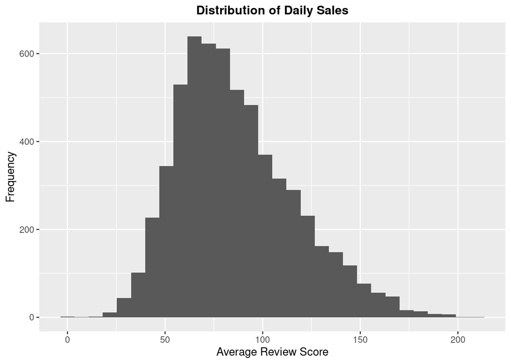

```r
#Check distribution of Daily Sales and any potential outlier
ggplot(book.data) + geom_histogram(aes(daily.sales))+
  labs(title = "Distribution of Daily Sales",
       x = "Average Review Score", y = "Frequency")+
  theme(plot.title = element_text(size = 12, face = "bold", hjust = 0.5))
```

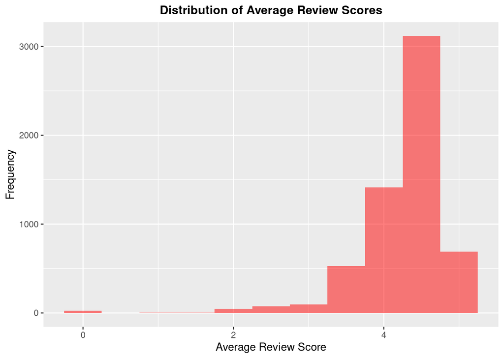

```r
# Histogram to check the distribution of total reviews and average review scores

ggplot(book.data, aes(x = avg.review)) +
  geom_histogram(binwidth = 0.5, fill ="red",alpha = 0.5) +
  labs(title = "Distribution of Average Review Scores",
       x = "Average Review Score", y = "Frequency")+
  theme(plot.title = element_text(size = 12, face = "bold", hjust = 0.5))
```